# Lab 13

Author

Jazlynn Bailey

```r
library(tidyverse)
library(janitor)
library(vegan)
library(DT)



NEON_MAGs <- read_tsv("/work/pi_bio678_umass_edu/data_NEON/exported_img_bins_Gs0166454_NEON.tsv",
                      show_col_types = FALSE) |>
  clean_names()

# Extract taxonomy into columns
NEON_MAGs_tax <- NEON_MAGs |>
  separate(
    gtdb_taxonomy_lineage,
    into = c("domain","phylum","class","order","family","genus","species"),
    sep = ";\\s*",
    fill = "right",
    extra = "drop"
  )

# Build joinID from genome_name
NEON_MAGs_tax <- NEON_MAGs_tax |>
  mutate(
    joinID = str_extract(genome_name, "[A-Z]{4}_[0-9]{3}-[A-Z]-[0-9]{8}")
  )

# -------------------------------------------------------------------
# Load output from Lab 12 (ex5_with_site + chemistry)
# -------------------------------------------------------------------

# Re-run minimal Lab 12 core to ensure the objects exist
soilChem <- readRDS("/work/pi_bio678_umass_edu/data_NEON/soilChem.rds")

genomicSamples <- soilChem$sls_metagenomicsPooling |>
  separate(genomicsPooledIDList, into = c("first","second","third"),
           sep="\\|", fill="right") |>
  select(genomicsSampleID, first, second, third)

genSampleExample <- genomicSamples |>
  pivot_longer(cols = c(first,second,third), values_to = "sampleID") |>
  select(sampleID, genomicsSampleID) |>
  drop_na()

chemEx <- soilChem$sls_soilMoisture |>
  select(sampleID, soilMoisture)

combinedTab <- left_join(genSampleExample, chemEx, by="sampleID") |> drop_na()

soilpH_Example <- soilChem$sls_soilpH |>
  filter(sampleID %in% combinedTab$sampleID) |>
  select(sampleID, soilInWaterpH, soilInCaClpH)

combinedTab_pH <- left_join(combinedTab, soilpH_Example, by="sampleID")

# pH averaging function
mean_pH <- function(x) {
  h <- 10^(-x)
  -log10(mean(h, na.rm = TRUE))
}

genome_groups_all_mean <- combinedTab_pH |>
  group_by(genomicsSampleID) |>
  summarize(
    soilMoisture = mean(soilMoisture, na.rm=TRUE),
    soilInWaterpH = mean_pH(soilInWaterpH),
    soilInCaClpH = mean_pH(soilInCaClpH)
  )

# Add site + joinID
ex5_with_site <- genome_groups_all_mean |>
  mutate(
    siteID = substr(genomicsSampleID, 1, 4),
    joinID = str_remove(genomicsSampleID, "-COMP$")
  )

# -------------------------------------------------------------------
# Join MAG taxonomy with soil chemistry
# -------------------------------------------------------------------

ex7_master <- left_join(ex5_with_site, NEON_MAGs_tax, by = "joinID")

datatable(head(ex7_master, 20), caption = "Joined MAG + Chemistry Table")
```

|  | genomicsSampleID | soilMoisture | soilInWaterpH | soilInCaClpH | siteID | joinID | bin_oid | bin_id | genome_name | img_genome_id | bin_quality | bin_lineage | domain | phylum | class | order | family | genus | species | bin_methods | created_by | date_added | bin_completeness | bin_contamination | average_coverage | total_number_of_bases | x5s_r_rna | x16s_r_rna | x23s_r_rna | … |
| --- | --- | --- | --- | --- | --- | --- | --- | --- | --- | --- | --- | --- | --- | --- | --- | --- | --- | --- | --- | --- | --- | --- | --- | --- | --- | --- | --- | --- | --- | --- |
| 1 | BONA_001-O-20230710-COMP | 1.546 | 3.993976181886937 | 3.449950654161424 | BONA | BONA_001-O-20230710 | 3300079481_s0 | 3300079481_s0 | Soil microbial communities from Caribou-Poker Creeks Research Watershed NEON Field Site, Alaska, USA - BONA_001-O-20230710-COMP-DNA1 | 3300079481 | MQ | Bacteria; Acidobacteriota; Terriglobia | Bacteria | Acidobacteriota | Terriglobia | Terriglobales | SbA1 | Sulfotelmatobacter |  | SemiBin2:v2.1.0, CheckM2:v1.0.2, GTDB-Tk:v2.4.0, GTDB-Tk-database:release220 | IMG_PIPELINE | 2025-02-03 | 95.61 | 4.96 |  | 6486507 | 1 | 1 | 0 | … |
| 2 | BONA_001-O-20230710-COMP | 1.546 | 3.993976181886937 | 3.449950654161424 | BONA | BONA_001-O-20230710 | 3300079481_s1 | 3300079481_s1 | Soil microbial communities from Caribou-Poker Creeks Research Watershed NEON Field Site, Alaska, USA - BONA_001-O-20230710-COMP-DNA1 | 3300079481 | HQ | Bacteria; Actinomycetota; Thermoleophilia; Solirubrobacterales | Bacteria | Actinomycetota | Thermoleophilia | Solirubrobacterales | Solirubrobacteraceae | Palsa-744 |  | SemiBin2:v2.1.0, CheckM2:v1.0.2, GTDB-Tk:v2.4.0, GTDB-Tk-database:release220 | IMG_PIPELINE | 2025-02-03 | 94.66 | 1.99 |  | 3237739 | 1 | 1 | 2 | … |
| 3 | BONA_001-O-20230710-COMP | 1.546 | 3.993976181886937 | 3.449950654161424 | BONA | BONA_001-O-20230710 | 3300079481_s101 | 3300079481_s101 | Soil microbial communities from Caribou-Poker Creeks Research Watershed NEON Field Site, Alaska, USA - BONA_001-O-20230710-COMP-DNA1 | 3300079481 | MQ | Bacteria; Actinomycetota; Thermoleophilia; Solirubrobacterales | Bacteria | Actinomycetota | Thermoleophilia | Solirubrobacterales | Solirubrobacteraceae | Palsa-744 |  | SemiBin2:v2.1.0, CheckM2:v1.0.2, GTDB-Tk:v2.4.0, GTDB-Tk-database:release220 | IMG_PIPELINE | 2025-02-03 | 51.78 | 9.42 |  | 2712910 | 1 | 1 | 1 | … |
| 4 | BONA_001-O-20230710-COMP | 1.546 | 3.993976181886937 | 3.449950654161424 | BONA | BONA_001-O-20230710 | 3300079481_s11 | 3300079481_s11 | Soil microbial communities from Caribou-Poker Creeks Research Watershed NEON Field Site, Alaska, USA - BONA_001-O-20230710-COMP-DNA1 | 3300079481 | MQ | Bacteria; Acidobacteriota; Terriglobia; Terriglobales | Bacteria | Acidobacteriota | Terriglobia | Terriglobales | SbA1 | Sulfotelmatobacter |  | SemiBin2:v2.1.0, CheckM2:v1.0.2, GTDB-Tk:v2.4.0, GTDB-Tk-database:release220 | IMG_PIPELINE | 2025-02-03 | 60.83 | 0.04 |  | 2720369 | 0 | 0 | 0 | … |
| 5 | BONA_001-O-20230710-COMP | 1.546 | 3.993976181886937 | 3.449950654161424 | BONA | BONA_001-O-20230710 | 3300079481_s15 | 3300079481_s15 | Soil microbial communities from Caribou-Poker Creeks Research Watershed NEON Field Site, Alaska, USA - BONA_001-O-20230710-COMP-DNA1 | 3300079481 | MQ | Bacteria; Acidobacteriota | Bacteria | Acidobacteriota | Terriglobia | Acidoferrales | UBA7541 | Palsa-295 |  | SemiBin2:v2.1.0, CheckM2:v1.0.2, GTDB-Tk:v2.4.0, GTDB-Tk-database:release220 | IMG_PIPELINE | 2025-02-03 | 81.54 | 0.18 |  | 3539081 | 0 | 0 | 0 | … |
| 6 | BONA_001-O-20230710-COMP | 1.546 | 3.993976181886937 | 3.449950654161424 | BONA | BONA_001-O-20230710 | 3300079481_s2 | 3300079481_s2 | Soil microbial communities from Caribou-Poker Creeks Research Watershed NEON Field Site, Alaska, USA - BONA_001-O-20230710-COMP-DNA1 | 3300079481 | MQ | Bacteria; Acidobacteriota; Terriglobia; Terriglobales | Bacteria | Acidobacteriota | Terriglobia | Terriglobales | SbA1 | Sulfotelmatobacter |  | SemiBin2:v2.1.0, CheckM2:v1.0.2, GTDB-Tk:v2.4.0, GTDB-Tk-database:release220 | IMG_PIPELINE | 2025-02-03 | 88.11 | 0.19 |  | 3957793 | 1 | 0 | 0 | … |
| 7 | BONA_001-O-20230710-COMP | 1.546 | 3.993976181886937 | 3.449950654161424 | BONA | BONA_001-O-20230710 | 3300079481_s23 | 3300079481_s23 | Soil microbial communities from Caribou-Poker Creeks Research Watershed NEON Field Site, Alaska, USA - BONA_001-O-20230710-COMP-DNA1 | 3300079481 | MQ |  | Bacteria | Actinomycetota | Actinomycetes | Streptosporangiales | Streptosporangiaceae | Palsa-504 |  | SemiBin2:v2.1.0, CheckM2:v1.0.2, GTDB-Tk:v2.4.0, GTDB-Tk-database:release220 | IMG_PIPELINE | 2025-02-03 | 77.19 | 4.25 |  | 6054409 | 0 | 0 | 0 | … |
| 8 | BONA_001-O-20230710-COMP | 1.546 | 3.993976181886937 | 3.449950654161424 | BONA | BONA_001-O-20230710 | 3300079481_s24 | 3300079481_s24 | Soil microbial communities from Caribou-Poker Creeks Research Watershed NEON Field Site, Alaska, USA - BONA_001-O-20230710-COMP-DNA1 | 3300079481 | MQ | Bacteria; Pseudomonadota; Gammaproteobacteria | Bacteria | Pseudomonadota | Gammaproteobacteria | Steroidobacterales | Steroidobacteraceae | Bog-1198 |  | SemiBin2:v2.1.0, CheckM2:v1.0.2, GTDB-Tk:v2.4.0, GTDB-Tk-database:release220 | IMG_PIPELINE | 2025-02-03 | 66.34 | 0.66 |  | 2329620 | 0 | 0 | 0 | … |
| 9 | BONA_001-O-20230710-COMP | 1.546 | 3.993976181886937 | 3.449950654161424 | BONA | BONA_001-O-20230710 | 3300079481_s25 | 3300079481_s25 | Soil microbial communities from Caribou-Poker Creeks Research Watershed NEON Field Site, Alaska, USA - BONA_001-O-20230710-COMP-DNA1 | 3300079481 | MQ | Bacteria; Acidobacteriota; Terriglobia | Bacteria | Acidobacteriota | Terriglobia | Bryobacterales | Bryobacteraceae | Palsa-89 |  | SemiBin2:v2.1.0, CheckM2:v1.0.2, GTDB-Tk:v2.4.0, GTDB-Tk-database:release220 | IMG_PIPELINE | 2025-02-03 | 66.1 | 0.16 |  | 4300045 | 0 | 0 | 0 | … |
| 10 | BONA_001-O-20230710-COMP | 1.546 | 3.993976181886937 | 3.449950654161424 | BONA | BONA_001-O-20230710 | 3300079481_s3 | 3300079481_s3 | Soil microbial communities from Caribou-Poker Creeks Research Watershed NEON Field Site, Alaska, USA - BONA_001-O-20230710-COMP-DNA1 | 3300079481 | MQ | Bacteria; Acidobacteriota; Terriglobia; Terriglobales | Bacteria | Acidobacteriota | Terriglobia | Terriglobales | SbA1 | QIAJ01 |  | SemiBin2:v2.1.0, CheckM2:v1.0.2, GTDB-Tk:v2.4.0, GTDB-Tk-database:release220 | IMG_PIPELINE | 2025-02-03 | 66.93 | 3.17 |  | 4009333 | 0 | 0 | 0 | … |

[output cut: 10 more lines]

```r
mags <- ex7_master
```

# Introduction

This lab explores microbial community composition using Metagenome Assembled Genomes from NEON soil samples. Since the dataset contains only presence information for each MAG, diversity metrics reflect the number of unique taxa rather than true abundance. The goal is to understand taxonomic patterns across sites and compute alpha, beta, and ordination-based diversity.

# Data Overview

```r
glimpse(mags)
```

```
Rows: 5,608
Columns: 33
$ genomicsSampleID      <chr> "BONA_001-O-20230710-COMP", "BONA_001-O-20230710…
$ soilMoisture          <dbl> 1.546, 1.546, 1.546, 1.546, 1.546, 1.546, 1.546,…
$ soilInWaterpH         <dbl> 3.993976, 3.993976, 3.993976, 3.993976, 3.993976…
$ soilInCaClpH          <dbl> 3.449951, 3.449951, 3.449951, 3.449951, 3.449951…
$ siteID                <chr> "BONA", "BONA", "BONA", "BONA", "BONA", "BONA", …
$ joinID                <chr> "BONA_001-O-20230710", "BONA_001-O-20230710", "B…
$ bin_oid               <chr> "3300079481_s0", "3300079481_s1", "3300079481_s1…
$ bin_id                <chr> "3300079481_s0", "3300079481_s1", "3300079481_s1…
$ genome_name           <chr> "Soil microbial communities from Caribou-Poker C…
$ img_genome_id         <dbl> 3300079481, 3300079481, 3300079481, 3300079481, …
$ bin_quality           <chr> "MQ", "HQ", "MQ", "MQ", "MQ", "MQ", "MQ", "MQ", …
$ bin_lineage           <chr> "Bacteria; Acidobacteriota; Terriglobia", "Bacte…
$ domain                <chr> "Bacteria", "Bacteria", "Bacteria", "Bacteria", …
```

[output cut: 20 more lines]

```r
names(mags)
```

```
 [1] "genomicsSampleID"      "soilMoisture"          "soilInWaterpH"
 [4] "soilInCaClpH"          "siteID"                "joinID"
 [7] "bin_oid"               "bin_id"                "genome_name"
[10] "img_genome_id"         "bin_quality"           "bin_lineage"
[13] "domain"                "phylum"                "class"
[16] "order"                 "family"                "genus"
[19] "species"               "bin_methods"           "created_by"
[22] "date_added"            "bin_completeness"      "bin_contamination"
[25] "average_coverage"      "total_number_of_bases" "x5s_r_rna"
[28] "x16s_r_rna"            "x23s_r_rna"            "t_rna_genes"
[31] "gene_count"            "scaffold_count"        "gold_study_id"
```

# Taxonomic Profiling

We begin by summarizing how many MAGs from each phylum appear at each site.

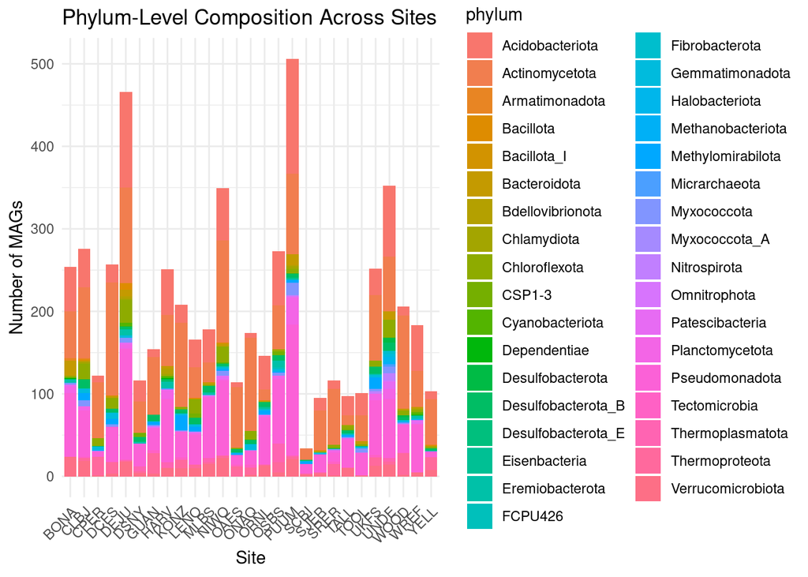

```r
mags <- mags |> rename(site_id = siteID)

taxa_counts <- mags |>
  filter(!is.na(phylum)) |>
  count(site_id, phylum)

ggplot(taxa_counts, aes(x = site_id, y = n, fill = phylum)) +
  geom_col() +
  labs(title = "Phylum-Level Composition Across Sites",
       x = "Site",
       y = "Number of MAGs") +
  theme_minimal() +
  theme(axis.text.x = element_text(angle = 45, hjust = 1))
```

Explanation: This bar chart shows how many MAGs from each phylum appear at each site. Since we do not have abundance values, each MAG counts as one presence.

# Alpha Diversity

We compute Shannon, Simpson, and richness for each site.

```r
alpha_data <- mags |>
  filter(!is.na(phylum)) |>
  count(site_id, phylum) |>
  group_by(site_id) |>
  summarize(
    richness = n(),
    shannon = diversity(n, index = "shannon"),
    simpson = diversity(n, index = "simpson")
  )

alpha_data
```

```
# A tibble: 27 × 4
   site_id richness shannon simpson
   <chr>      <int>   <dbl>   <dbl>
 1 BONA          15    1.85   0.797
 2 CLBJ          18    2.06   0.819
 3 CPER          10    1.43   0.640
 4 DCFS          14    1.62   0.674
 5 DEJU          19    1.87   0.786
 6 DSNY          11    1.82   0.787
 7 GUAN          12    1.68   0.728
 8 HARV          17    1.91   0.791
 9 KONZ          12    1.68   0.713
10 LENO          13    2.05   0.838
# ℹ 17 more rows
```

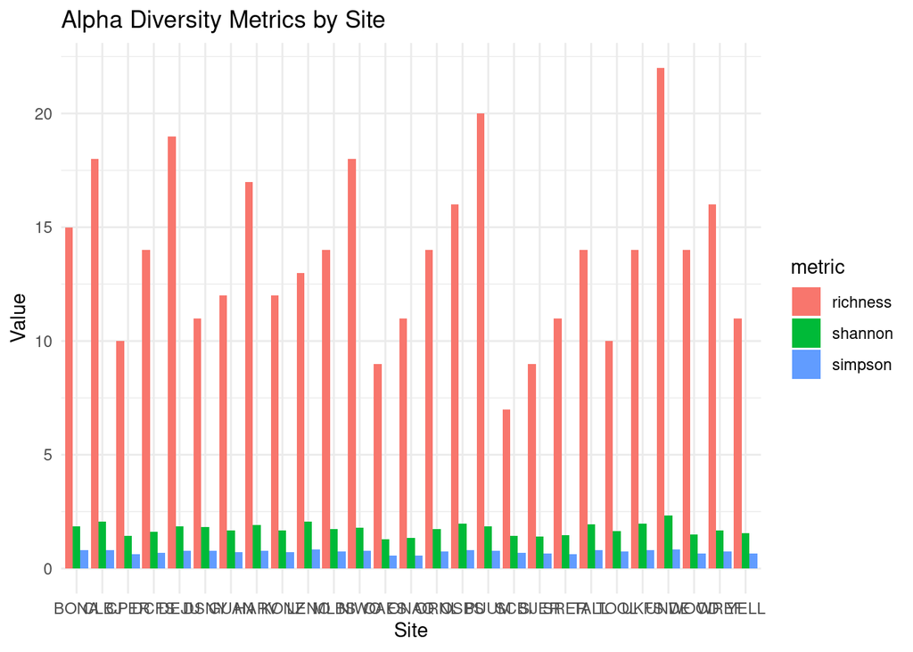

```r
alpha_data_long <- alpha_data |>
  pivot_longer(
    cols = c(richness, shannon, simpson),
    names_to = "metric",
    values_to = "value"
  )

ggplot(alpha_data_long, aes(x = site_id, y = value, fill = metric)) +
  geom_col(position = "dodge") +
  labs(
    title = "Alpha Diversity Metrics by Site",
    x = "Site",
    y = "Value"
  ) +
  theme_minimal()
```

# Beta Diversity

```r
pa_matrix <- mags |>
  filter(!is.na(phylum)) |>
  count(site_id, phylum) |>
  pivot_wider(
    names_from = phylum,
    values_from = n,
    values_fill = 0
  )

site_ids <- pa_matrix$site_id

pa_matrix <- pa_matrix |> select(-site_id)

bray <- vegdist(pa_matrix, method = "bray")
bray
```

```
           1         2         3         4         5         6         7
2  0.2792453
3  0.6117021 0.4924623
4  0.4951076 0.2833021 0.4089710
5  0.3611111 0.3261456 0.6700680 0.4218534
6  0.4702703 0.4642857 0.5210084 0.4852547 0.6460481
7  0.5196078 0.4046512 0.2028986 0.3479319 0.6258065 0.3777778
8  0.1366337 0.2827324 0.5710456 0.4645669 0.3528591 0.4114441 0.4765432
9  0.4718615 0.2809917 0.3939394 0.2000000 0.4807122 0.3950617 0.2651934
10 0.4238095 0.2805430 0.5069444 0.3853428 0.5379747 0.2411348 0.4125000
11 0.2546296 0.3392070 0.7066667 0.5356322 0.4844720 0.3469388 0.5481928
12 0.2570481 0.2032000 0.5796178 0.2739274 0.1877301 0.5569892 0.5228628
13 0.5869565 0.4615385 0.1779661 0.3908356 0.6620690 0.4521739 0.1865672
14 0.6074766 0.3955556 0.2905405 0.2157773 0.5125000 0.5103448 0.3048780
15 0.3500000 0.3364929 0.7462687 0.5384615 0.5588235 0.3893130 0.5666667
16 0.2333966 0.3187614 0.5645570 0.4566038 0.3856563 0.4035990 0.4660422
17 0.3815789 0.3836317 0.6942675 0.5072084 0.1728395 0.6688103 0.6272727
18 0.8055556 0.7806452 0.6794872 0.7663230 0.8760000 0.6000000 0.6382979
19 0.4899713 0.4878706 0.3732719 0.4715909 0.6648841 0.2322275 0.3253012
20 0.5405405 0.4744898 0.1512605 0.4101877 0.6563574 0.4310345 0.2000000
21 0.5156695 0.4852547 0.6803653 0.5254237 0.6696270 0.2957746 0.5219124
22 0.4704225 0.4801061 0.5426009 0.4916201 0.6437390 0.2073733 0.4431373
23 0.2885375 0.1553030 0.4331551 0.2848723 0.4038997 0.4293478 0.3251232
24 0.2739274 0.2643312 0.5822785 0.4679803 0.2933985 0.5341880 0.5217391
25 0.5304348 0.3651452 0.2865854 0.1749460 0.4761905 0.4782609 0.2111111
26 0.2082380 0.2941176 0.5803279 0.4636364 0.4545455 0.3444816 0.4836795
27 0.5462185 0.5197889 0.2000000 0.4611111 0.6906854 0.4246575 0.2684825
           8         9        10        11        12        13        14
2
3
4
5
6
7
8
9  0.4335512
10 0.4004796 0.3582888
11 0.2354312 0.5025907 0.3139535
12 0.2700000 0.3572711 0.4213592 0.3738140
13 0.5342466 0.3043478 0.5142857 0.6643836 0.5593952
```

[output cut: 53 more lines]

```
13
14
15
16
17
18
19
20
21
22
23 0.4617564
24 0.5540839 0.2913907
25 0.4918567 0.3318777 0.5161290
26 0.3450704 0.3287356 0.3532710 0.4961440
27 0.4901961 0.4591549 0.6043956 0.3786408 0.5174825
```

Explanation: Bray Curtis measures dissimilarity between sites based on their MAG composition. Values closer to 0 indicate similar communities. Values closer to 1 indicate large differences.

# NMDS Ordination

We use non-metric multidimensional scaling to visualize similarities among sites.

```r
nmds_result <- metaMDS(pa_matrix, distance = "bray", k = 2, trymax = 50)
```

```
Square root transformation
Wisconsin double standardization
*** Best solution repeated 1 times
```

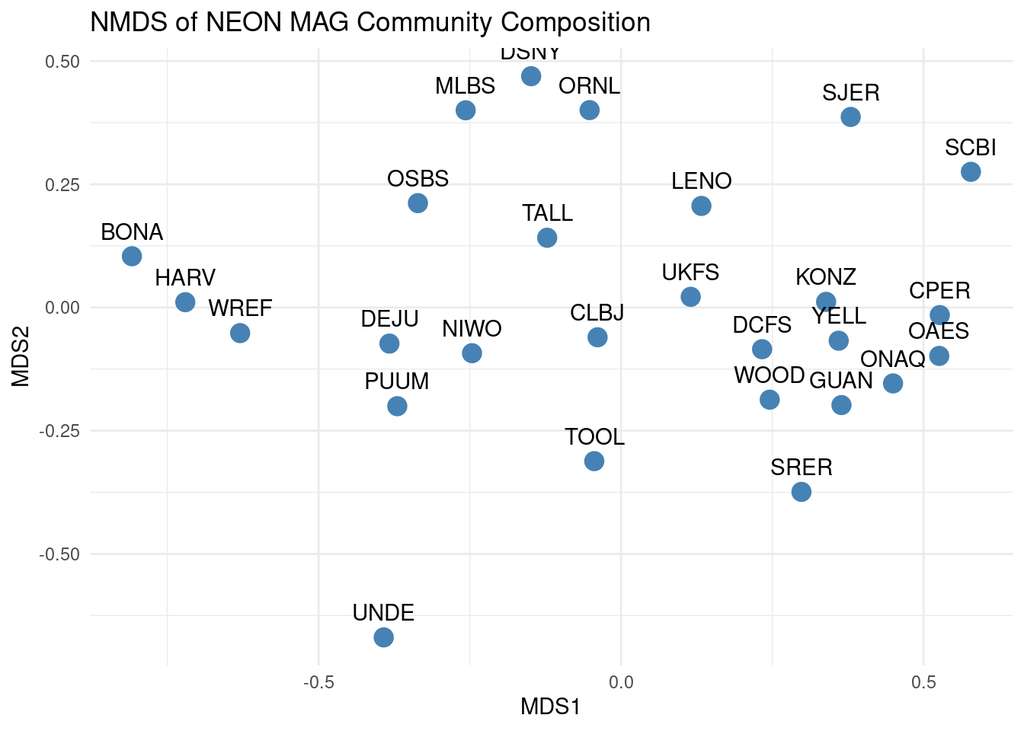

```r
nmds_points <- as.data.frame(nmds_result$points)
nmds_points$site_id <- site_ids

ggplot(nmds_points, aes(x = MDS1, y = MDS2, label = site_id)) +
  geom_point(size = 4, color = "steelblue") +
  geom_text(vjust = -1) +
  labs(
    title = "NMDS of NEON MAG Community Composition",
    x = "MDS1",
    y = "MDS2"
  ) +
  theme_minimal()
```

Explanation: NMDS places sites in a 2D space based on ecological distance. Sites closer together share more similar MAG compositions. This method works well with presence absence data.

# Conclusion

This analysis explored: • Phylum-level community structure • Diversity within each site • Dissimilarity between sites • Ordination patterns based on Bray Curtis distance

The dataset provides a basic view of soil microbial composition. Richness and phylum profiles vary across sites, and NMDS offers a visual summary of ecological relationships. True abundance counts would improve interpretation, but presence-based metrics still reveal meaningful structure.